# Case Study 1

# Geology

Lets start by reading in QAP matrix:

```r
rock_comp <- matrix(c(43.18, 22.49, 34.33,
                      8.19, 34.61, 57.20,
                      27.28, 55.12, 17.60,
                      62.95, 16.55, 20.50,
                      47.83, 11.77, 40.39,
                      58.92, 6.50, 34.58,
                      18.42, 21.35, 60.23,
                      18.38, 15.16, 66.47,
                      19.41, 42.25, 38.34,
                      65.16, 1.91, 32.93,
                      29.43, 24.08, 46.49,
                      25.32, 36.72, 37.96,
                      11.66, 46.38, 41.96,
                      40.35, 23.41, 36.24,
                      52.34, 38.90, 8.76,
                      2.54, 67.07, 30.39,
                      55.56, 39.70, 4.74,
                      9.32, 20.84, 69.84,
                      39.24, 27.34, 33.42,
                      25.82, 40.90, 33.28,
                      31.66, 36.99, 31.34,
                      47.52, 27.74, 24.74,
                      33.00, 60.59, 6.41,
                      45.33, 7.94, 46.73,
                      14.68, 35.34, 49.99),
                    nrow=25, ncol=3, byrow = TRUE)
```

## #1

To start, I thought this would be easier if it was a dataframe so I turned it into a dataframe.

```r
rock_comp <- as.data.frame(rock_comp)

#setting column names
colnames(rock_comp) <- c("Q","A","P")

#creating new column that will be the class
rock_comp$class = NA

#creating p ratio that is a percentage
rock_comp$P_ratio <- (rock_comp$P/(rock_comp$A + rock_comp$P)) *100

for (i in 1:nrow(rock_comp)){
#this works on rocks above 60% quartz
  if (rock_comp$Q[i] > 60) {
    rock_comp$class[i] <- NA
  }


#this works on rocks between 20 and 60% quartz
  else if (rock_comp$Q[i] < 60 & rock_comp$Q[i] > 20) {
    if (rock_comp$P_ratio[i] > 65) {
      rock_comp$class[i] <- "dacite"
    }
    else {
    rock_comp$class[i] <- "rhyolite"
    }
  }


#this works on rocks between 0 and 20% quartz
  else if (rock_comp$Q[i] < 20){
    if (rock_comp$P_ratio[i] > 65){
      rock_comp$class[i] <- "andesite/basalt"
    }
    else if (rock_comp$P_ratio[i] > 35 & rock_comp$P_ratio[i] < 65){
      rock_comp$class[i] <- "latite"
    }
    else {
      rock_comp$class[i] <- "trachyte"
    }
  }
}
```

Let’s plot the distribution of classes

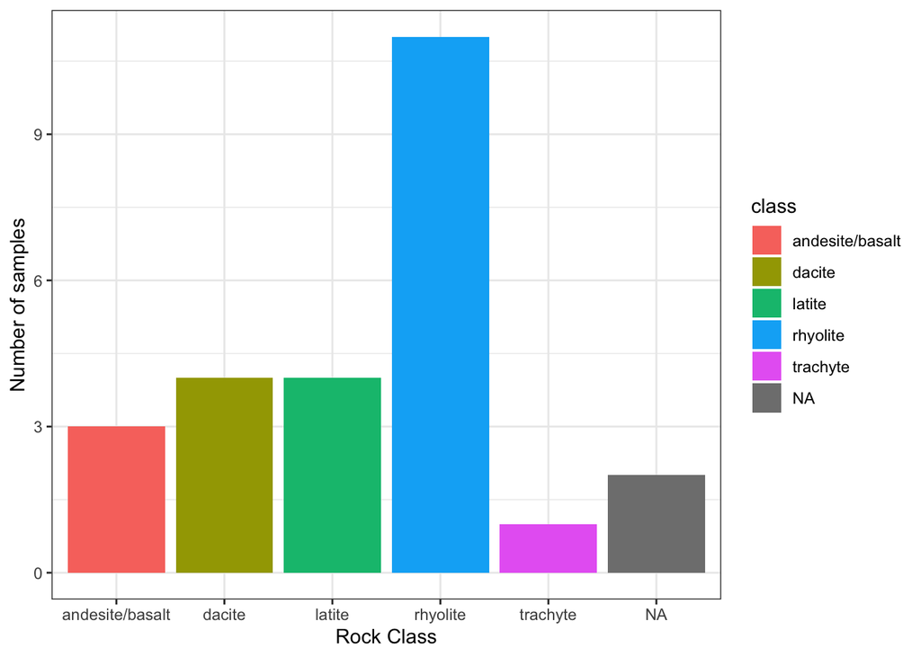

```r
rock_comp %>%
  ggplot(aes(x=class,fill=class)) +
  geom_bar() +
  labs(x="Rock Class",
       y= "Number of samples",
       main = "") +
  theme_bw()
```

## #2

I think this solution is efficient and correct if you are looking for those six classifications, it first splits into the three *if statements* for Q values and then proceeds to deal with the A and P values

# Geography

## #3

Moving onto the precipitation data, lets load it in and I wanted to create a column that is numeric months.

```r
precip_data <- data.frame(
  month = c("Jan", "Feb", "Mar", "Apr", "May", "Jun", "Jul", "Aug", "Sep", "Oct", "Nov", "Dec"),
  year1 = c(3.879, 10.430, 6.991, 10.071, 17.864, 21.627, 20.853, 16.377, 10.000, 2.754, 3.507, 5.033),
  year2 = c(4.540, 7.922, 8.719, 12.649, 19.564, 26.676, 19.410, 16.108, 12.000, 4.194, 2.943, -1.098),
  year3 = c(8.117, 4.470, 8.637, 11.067, 17.948, 25.307, 21.790, 14.876, 13.000, 4.067, 2.914, 3.169),
  year4 = c(5.141, 5.626, 9.217, 12.242, 18.542, 22.724, 21.756, 14.388, 15.000, 6.560, 5.737, 2.248),
  year5 = c(5.259, 6.109, 8.888, 14.054, 18.750, 27.508, 21.643, 14.239, 18.000, 4.833, 2.548, 2.432),
  ave30 = c(4.491, 6.015, 9.719, 14.322, 17.637, 23.872, 20.194, 14.301, 9.587, 3.585, 2.633, 1.460)
)

month_names <- precip_data$month

precip_data$month_numeric = c(1:12)
```

creating new vector with months above 30 year average for each year. Set the column as a color “blue” when true and “red” when false.

```r
for (i in 1:nrow(precip_data)) {
  if (precip_data$year1[i] > precip_data$ave30[i]) {
    precip_data$above1[i] = "blue"
  } else {
    precip_data$above1[i] = "red"
  }
  if (precip_data$year2[i] > precip_data$ave30[i]) {
    precip_data$above2[i] = "blue"
  } else {
    precip_data$above2[i] = "red"
  }
  if (precip_data$year3[i] > precip_data$ave30[i]) {
    precip_data$above3[i] = "blue"
  } else {
    precip_data$above3[i] = "red"
  }
  if (precip_data$year4[i] > precip_data$ave30[i]) {
    precip_data$above4[i] = "blue"
  } else {
    precip_data$above4[i] = "red"
  }
  if (precip_data$year5[i] > precip_data$ave30[i]) {
    precip_data$above5[i] = "blue"
  } else {
    precip_data$above5[i] = "red"
  }
}
```

```r
long_precip <- pivot_longer(precip_data, cols = c(starts_with("year"),"ave30"),
                            names_to = "year",
                            values_to = "precip")

long_precip <- pivot_longer(long_precip, cols = starts_with("above"),
                            names_to = "above",
                            values_to = "color")
```

Because I turned it into longer columns it didn’t make sense to have the above value for each year that it wasn’t correlated with so I remove any values in the color column if the above row didn’t correlate with the year row.

```r
for (i in 1:nrow(long_precip)) {
  if (long_precip$year[i] == "year1" & long_precip$above[i] != "above1") {
    long_precip$color[i] = NA
  }
  if (long_precip$year[i] == "year2" & long_precip$above[i] != "above2") {
    long_precip$color[i] = NA
  }
  if (long_precip$year[i] == "year3" & long_precip$above[i] != "above3") {
    long_precip$color[i] = NA
  }
  if (long_precip$year[i] == "year4" & long_precip$above[i] != "above4") {
    long_precip$color[i] = NA
  }
  if (long_precip$year[i] == "year5" & long_precip$above[i] != "above5") {
    long_precip$color[i] = NA
  }
  if (long_precip$year[i] == "ave30") {
    long_precip$color[i] = "NULL"
  }
}

#remove rows with NA values in the "color" column
long_precip <- subset(long_precip, !is.na(color))
```

Let’s get plotting now!

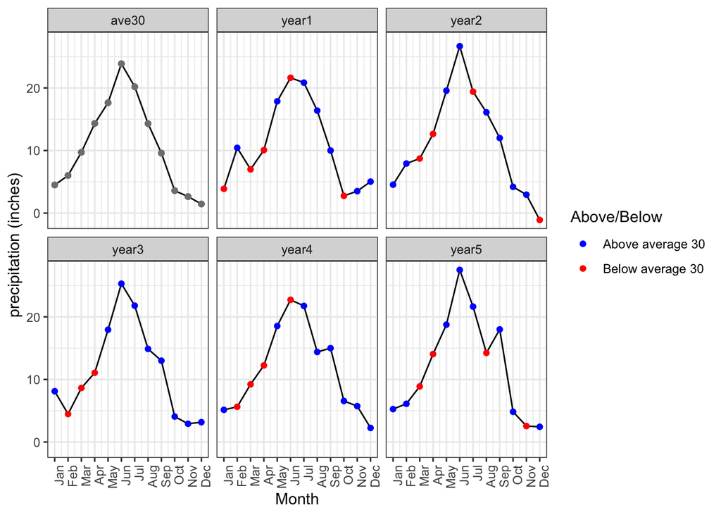

```r
long_precip %>%
ggplot(aes(x = month_numeric, y = precip)) +
  geom_line() +
  geom_point(aes(color = color)) +
  scale_color_manual(values = c("red" = "red", "blue" = "blue"),
                     labels = c("Above average 30", "Below average 30"),
                     name = "Above/Below") +
  facet_wrap(~year) +
  scale_x_continuous(breaks = 1:12, label = month_names) +
  theme_bw() +
  theme(axis.text.x = element_text(angle = 90, hjust = 1)) +
  labs(x="Month",
       y="precipitation (inches)")
```

## #4

Let’s look at the standard deviation based on the month for these 5 years:

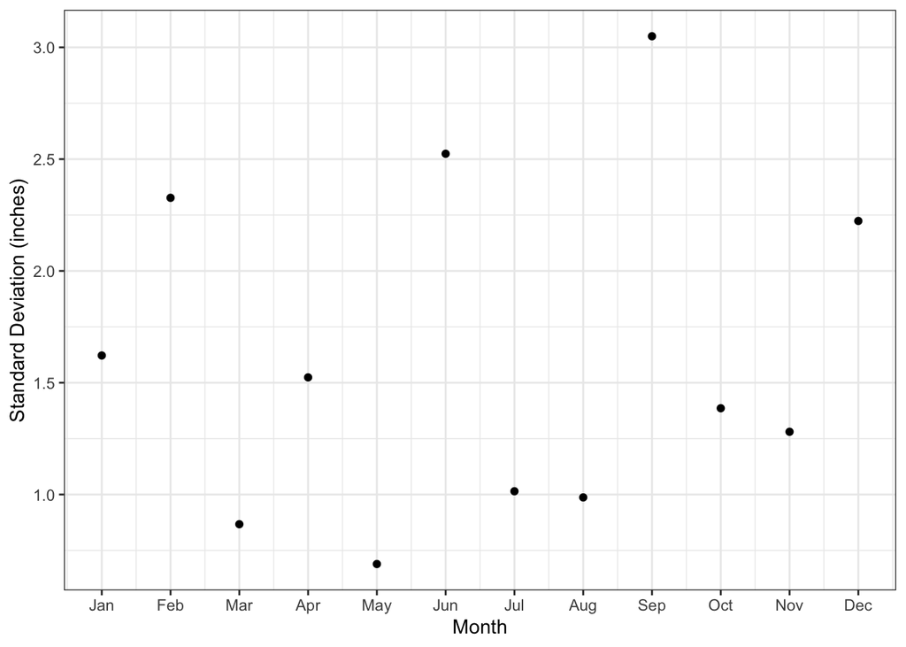

```r
avg5 = NULL
std_dev5 = NULL

for (i in 1:nrow(precip_data)) {
  average =
    ((precip_data$year1[i] +
    precip_data$year2[i] +
    precip_data$year3[i] +
    precip_data$year4[i] +
    precip_data$year5[i])/5)

    std_dev = sd(c(precip_data$year1[i],
                    precip_data$year2[i],
                    precip_data$year3[i],
                    precip_data$year4[i],
                    precip_data$year5[i]))

    avg5 = c(avg5, average)

    std_dev5 = c(std_dev5, std_dev)
}

precip_data$avg5 <- avg5
precip_data$std_dev5 <- std_dev5

precip_data %>%
  ggplot(aes(x=month_numeric,y=std_dev5)) +
  geom_point() +
  scale_x_continuous(breaks = 1:12, labels = month_names) +
  theme_bw() +
  labs(x="Month",
         y="Standard Deviation (inches)")
```

```r
#september has the highest standard deviation
```

September has the highest standard deviation and may has the lowest

Now let’s look at the average over the 5 years compared to the average over the 30 years:

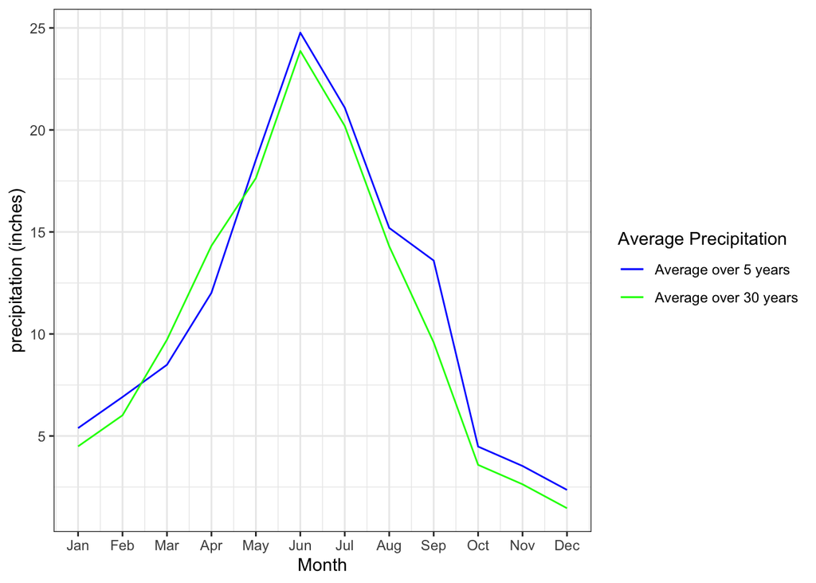

```r
precip_data %>%
  ggplot(aes(x=month_numeric)) +
  geom_line(aes(y=precip_data$avg5, color = "blue")) +
  geom_line(aes(y=precip_data$ave30, color = "green")) +
  scale_x_continuous(breaks = 1:12, labels = month_names) +
  scale_color_manual(values = c("blue", "green"),
                     name = "Average Precipitation",
                     labels = c("Average over 5 years", "Average over 30 years")) +
  theme_bw() +
  labs(x="Month",
       y="precipitation (inches)")
```

## #5

# Environmental Science

## #6

```r
# Environmental Science
river_df <- read.csv("./cs01_river_data.csv")

#making date column in date format
river_df$date <- as.Date(river_df$date)

#making sure the dates are in order
river_df <- river_df[order(river_df$date), ]

nitrate_site_1 <- river_df[river_df$nitrate > 5 & river_df$site_id == "site1",]
nitrate_site_2 <- river_df[river_df$nitrate > 5 & river_df$site_id == "site2",]
nitrate_site_3 <- river_df[river_df$nitrate > 5 & river_df$site_id == "site3",]
nitrate_site_4 <- river_df[river_df$nitrate > 5 & river_df$site_id == "site4",]

#checking how many weeks were above nitrate standard for each site
output <- c((paste0("nitrate was above standard for ",nrow(nitrate_site_1)," week(s) at site 1")),
(paste0("nitrate was above standard for ",nrow(nitrate_site_2)," week(s) at site 2")),
(paste0("nitrate was above standard for ",nrow(nitrate_site_3)," week(s) at site 3")),
(paste0("nitrate was above standard for ",nrow(nitrate_site_4)," week(s) at site 4")))

cat(output, sep = "\n")
```

```
## nitrate was above standard for 8 week(s) at site 1
## nitrate was above standard for 0 week(s) at site 2
## nitrate was above standard for 5 week(s) at site 3
## nitrate was above standard for 18 week(s) at site 4
```

```r
phosphate_site_1 <- river_df[river_df$phosphate > 2 & river_df$site_id == "site1",]
phosphate_site_2 <- river_df[river_df$phosphate > 2 & river_df$site_id == "site2",]
phosphate_site_3 <- river_df[river_df$phosphate > 2 & river_df$site_id == "site3",]
phosphate_site_4 <- river_df[river_df$phosphate > 2 & river_df$site_id == "site4",]

#checking how many weeks were above phosphate standard for each site
output <- c(
  paste0("phosphate was above standard for ", nrow(phosphate_site_1), " week(s) at site 1"),
  paste0("phosphate was above standard for ", nrow(phosphate_site_2), " week(s) at site 2"),
  paste0("phosphate was above standard for ", nrow(phosphate_site_3), " week(s) at site 3"),
  paste0("phosphate was above standard for ", nrow(phosphate_site_4), " week(s) at site 4")
)

cat(output, sep = "\n")
```

```
## phosphate was above standard for 6 week(s) at site 1
## phosphate was above standard for 0 week(s) at site 2
## phosphate was above standard for 4 week(s) at site 3
## phosphate was above standard for 37 week(s) at site 4
```

```r
both_site_1 <- river_df[river_df$phosphate > 2 & river_df$nitrate > 5 & river_df$site_id == "site1", ]
both_site_2 <- river_df[river_df$phosphate > 2 & river_df$nitrate > 5 & river_df$site_id == "site2", ]
both_site_3 <- river_df[river_df$phosphate > 2 & river_df$nitrate > 5 & river_df$site_id == "site3", ]
both_site_4 <- river_df[river_df$phosphate > 2 & river_df$nitrate > 5 & river_df$site_id == "site4", ]

#checking how many weeks were above phosphate and nitrate standard for each site
output <- c(
  paste0("nitrate AND phosphate were above standard for ", nrow(both_site_1), " week(s) at site 1"),
  paste0("nitrate AND phosphate were above standard for ", nrow(both_site_2), " week(s) at site 2"),
  paste0("nitrate AND phosphate were above standard for ", nrow(both_site_3), " week(s) at site 3"),
  paste0("nitrate AND phosphate were above standard for ", nrow(both_site_4), " week(s) at site 4")
)

cat(output, sep = "\n")
```

```
## nitrate AND phosphate were above standard for 4 week(s) at site 1
## nitrate AND phosphate were above standard for 0 week(s) at site 2
## nitrate AND phosphate were above standard for 3 week(s) at site 3
## nitrate AND phosphate were above standard for 10 week(s) at site 4
```

Site 4 seems to be of greatest concern, it has the most days over standard in phosphate and nitrate.

## #7

Let’s look when nitrate was above standard for 3 consecutive weeks at site 1:

```r
#finding times where it occured for 3 consecutive weeks for nitrate/site1
for (i in 1:(nrow(nitrate_site_1) - 2)) {

  start_date <- nitrate_site_1$date[i]
  end_date <- nitrate_site_1$date[i + 2]

  if (end_date - start_date == 14) {
    cat(paste0("Three consecutive weeks of nitrate above standard found at site1:\n"))
    cat(paste("Start Date:", start_date, "\n"))
    cat(paste("End Date:", end_date, "\n"))
    cat("\n")
  }
}
```

```
## Three consecutive weeks of nitrate above standard found at site1:
## Start Date: 2023-04-16
## End Date: 2023-04-30
##
## Three consecutive weeks of nitrate above standard found at site1:
## Start Date: 2023-04-23
## End Date: 2023-05-07
##
## Three consecutive weeks of nitrate above standard found at site1:
## Start Date: 2023-04-30
## End Date: 2023-05-14
##
## Three consecutive weeks of nitrate above standard found at site1:
## Start Date: 2023-10-01
## End Date: 2023-10-15
```

Let’s look when nitrate was above standard for 3 consecutive weeks at site 3:

```r
for (i in 1:(nrow(nitrate_site_3) - 2)) {

  start_date <- nitrate_site_3$date[i]
  end_date <- nitrate_site_3$date[i + 2]

  if (end_date - start_date == 14) {
    cat(paste0("Three consecutive weeks of nitrate above standard found at site3:\n"))
    cat(paste("Start Date:", start_date, "\n"))
    cat(paste("End Date:", end_date, "\n"))
    cat("\n")
  }
}
```

```
## Three consecutive weeks of nitrate above standard found at site3:
## Start Date: 2023-08-13
## End Date: 2023-08-27
```

Let’s look when nitrate was above standard for 3 consecutive weeks at site 4:

```r
for (i in 1:(nrow(nitrate_site_4) - 2)) {

  start_date <- nitrate_site_4$date[i]
  end_date <- nitrate_site_4$date[i + 2]

  if (end_date - start_date == 14) {
    cat(paste0("Three consecutive weeks of nitrate above standard found at site 4:\n"))
    cat(paste("Start Date:", start_date, "\n"))
    cat(paste("End Date:", end_date, "\n"))
    cat("\n")
  }
}
```

Let’s look when phosphate was above standard for 3 consecutive weeks at site 1:

```r
#now with phosphate
for (i in 1:(nrow(phosphate_site_1) - 2)) {

  start_date <- phosphate_site_1$date[i]
  end_date <- phosphate_site_1$date[i + 2]

  if (end_date - start_date == 14) {
    cat(paste0("Three consecutive weeks of phosphate above standard found at site 1:\n"))
    cat(paste("Start Date:", start_date, "\n"))
    cat(paste("End Date:", end_date, "\n"))
    cat("\n")
  }
}
```

```
## Three consecutive weeks of phosphate above standard found at site 1:
## Start Date: 2023-04-02
## End Date: 2023-04-16
##
## Three consecutive weeks of phosphate above standard found at site 1:
## Start Date: 2023-04-09
## End Date: 2023-04-23
##
## Three consecutive weeks of phosphate above standard found at site 1:
## Start Date: 2023-04-16
## End Date: 2023-04-30
##
## Three consecutive weeks of phosphate above standard found at site 1:
## Start Date: 2023-04-23
## End Date: 2023-05-07
```

Let’s look when phosphate was above standard for 3 consecutive weeks at site 3:

```r
for (i in 1:(nrow(phosphate_site_3) - 2)) {

  start_date <- phosphate_site_3$date[i]
  end_date <- phosphate_site_3$date[i + 2]

  if (end_date - start_date == 14) {
    cat(paste0("Three consecutive weeks of phosphate above standard found at site 3:\n"))
    cat(paste("Start Date:", start_date, "\n"))
    cat(paste("End Date:", end_date, "\n"))
    cat("\n")
  }
}
```

```
## Three consecutive weeks of phosphate above standard found at site 3:
## Start Date: 2023-08-13
## End Date: 2023-08-27
##
## Three consecutive weeks of phosphate above standard found at site 3:
## Start Date: 2023-08-20
## End Date: 2023-09-03
```

Let’s look when phosphate was above standard for 3 consecutive weeks at site 4:

```r
for (i in 1:(nrow(phosphate_site_4) - 2)) {

  start_date <- phosphate_site_4$date[i]
  end_date <- phosphate_site_4$date[i + 2]

  if (end_date - start_date == 14) {
    cat(paste0("Three consecutive weeks of phosphate above standard found at site 4:\n"))
    cat(paste("Start Date:", start_date, "\n"))
    cat(paste("End Date:", end_date, "\n"))
    cat("\n")
  }
}
```

```
## Three consecutive weeks of phosphate above standard found at site 4:
## Start Date: 2023-01-08
## End Date: 2023-01-22
##
## Three consecutive weeks of phosphate above standard found at site 4:
## Start Date: 2023-01-15
## End Date: 2023-01-29
##
## Three consecutive weeks of phosphate above standard found at site 4:
## Start Date: 2023-01-22
## End Date: 2023-02-05
##
## Three consecutive weeks of phosphate above standard found at site 4:
## Start Date: 2023-02-19
## End Date: 2023-03-05
##
## Three consecutive weeks of phosphate above standard found at site 4:
## Start Date: 2023-05-14
## End Date: 2023-05-28
##
## Three consecutive weeks of phosphate above standard found at site 4:
## Start Date: 2023-06-25
## End Date: 2023-07-09
##
## Three consecutive weeks of phosphate above standard found at site 4:
## Start Date: 2023-07-02
## End Date: 2023-07-16
##
## Three consecutive weeks of phosphate above standard found at site 4:
## Start Date: 2023-07-30
## End Date: 2023-08-13
##
## Three consecutive weeks of phosphate above standard found at site 4:
## Start Date: 2023-08-06
## End Date: 2023-08-20
##
## Three consecutive weeks of phosphate above standard found at site 4:
## Start Date: 2023-10-22
## End Date: 2023-11-05
##
## Three consecutive weeks of phosphate above standard found at site 4:
## Start Date: 2023-11-26
## End Date: 2023-12-10
##
## Three consecutive weeks of phosphate above standard found at site 4:
## Start Date: 2023-12-03
## End Date: 2023-12-17
##
## Three consecutive weeks of phosphate above standard found at site 4:
## Start Date: 2023-12-10
## End Date: 2023-12-24
##
## Three consecutive weeks of phosphate above standard found at site 4:
## Start Date: 2023-12-17
## End Date: 2023-12-31
```

Let’s look when phosphate AND nitrate were above standard for 3 consecutive weeks at site 1:

```r
#now for both sites
for (i in 1:(nrow(both_site_1) - 2)) {

  start_date <- both_site_1$date[i]
  end_date <- both_site_1$date[i + 2]

  if (end_date - start_date == 14) {
    cat(paste0("Three consecutive weeks of phosphate and nitrate above standard found at site 1:\n"))
    cat(paste("Start Date:", start_date, "\n"))
    cat(paste("End Date:", end_date, "\n"))
    cat("\n")
  }
}
```

```
## Three consecutive weeks of phosphate and nitrate above standard found at site 1:
## Start Date: 2023-04-16
## End Date: 2023-04-30
##
## Three consecutive weeks of phosphate and nitrate above standard found at site 1:
## Start Date: 2023-04-23
## End Date: 2023-05-07
```

Let’s look when phosphate AND nitrate were above standard for 3 consecutive weeks at site 3:

```r
for (i in 1:(nrow(both_site_3) - 2)) {

  start_date <- both_site_3$date[i]
  end_date <- both_site_3$date[i + 2]

  if (end_date - start_date == 14) {
    cat(paste0("Three consecutive weeks of phosphate and nitrate above standard found at site 3:\n"))
    cat(paste("Start Date:", start_date, "\n"))
    cat(paste("End Date:", end_date, "\n"))
    cat("\n")
  }
}
```

```
## Three consecutive weeks of phosphate and nitrate above standard found at site 3:
## Start Date: 2023-08-13
## End Date: 2023-08-27
```

Let’s look when phosphate AND nitrate were above standard for 3 consecutive weeks at site 4:

```r
for (i in 1:(nrow(both_site_4) - 2)) {

  start_date <- both_site_4$date[i]
  end_date <- both_site_4$date[i + 2]

  if (end_date - start_date == 14) {
    cat(paste0("Three consecutive weeks of phosphate and nitrate above standard found at site 4:\n"))
    cat(paste("Start Date:", start_date, "\n"))
    cat(paste("End Date:", end_date, "\n"))
    cat("\n")
  }
}
```

April seems to be the most common time for nitrate and phosphate to peak, specifically at site 1.

## #8

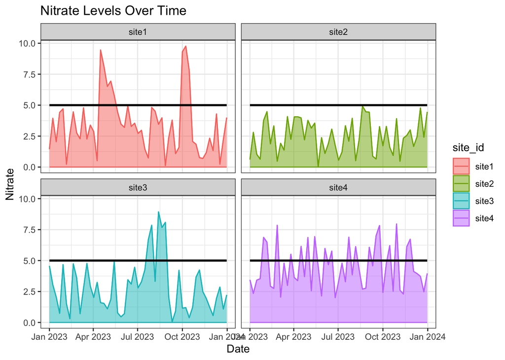

```r
#8
river_df %>%
  ggplot(aes(x=date,y=nitrate,color = site_id)) +
  geom_line() +
  geom_ribbon(aes(ymin = 0, ymax = nitrate,fill = site_id), alpha = 0.5) +
  labs(title = "Nitrate Levels Over Time",
       x = "Date",
       y = "Nitrate") +
  facet_wrap(~site_id) +
  geom_line(y=5,linewidth = 1,color = "black") +
  theme_bw()
```

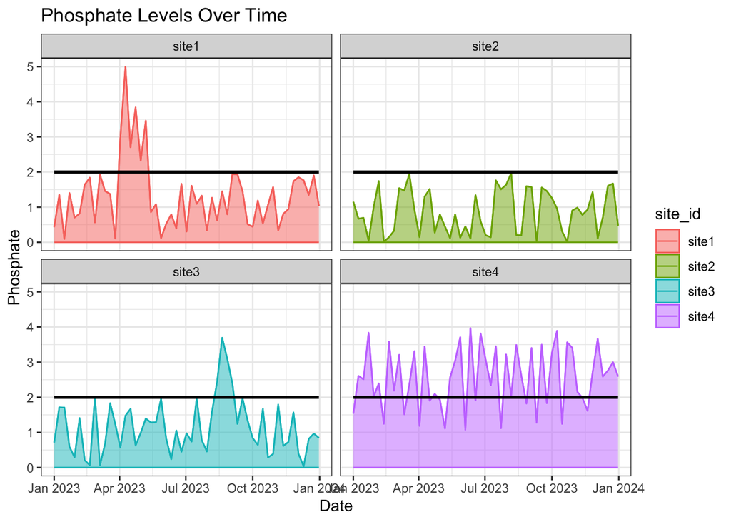

```r
river_df %>%
  ggplot(aes(x=date,y=phosphate,color = site_id)) +
  geom_line() +
  geom_ribbon(aes(ymin = 0, ymax = phosphate,fill = site_id), alpha = 0.5) +
  labs(title = "Phosphate Levels Over Time",
       x = "Date",
       y = "Phosphate") +
  facet_wrap(~site_id) +
  geom_line(y=2,linewidth = 1,color = "black") +
  theme_bw()
```

Given the black line indicating the standard, site 2 is the only sight that does not need to take action for remediation efforts. Site 4 must look at their stream sources and fix the issue immediately, as this sight is above standard majority of the time for phosphate levels, and frequently above standard for nitrate levels.

# Solar Farm Production Analyst

## #9

```r
# 30 days of energy production (kWh)
production <- c(1500, 1480, 1530, 1510, 1470, 1490, 1460, 1450, 1520, 1495,
                1510, 1520, 1500, 1490, 1540, 1560, 1480, 1470, 1500, 1480,
                1490, 1520, 1540, 1510, 1480, 1500, 1520, 1490, 1510, 1470)

# 30 days of solar irradiation (kW/m2)
irradiation <- c(0.8, 0.7, 0.9, 0.85, 0.6, 0.75, 0.65, 0.7, 0.8, 0.78,
                 0.82, 0.85, 0.78, 0.83, 0.86, 0.82, 0.8, 0.68, 0.92, 0.89,
                 0.82, 0.85, 0.86, 0.8, 0.73, 0.81, 0.85, 0.9, 0.92, 0.88)

# 30 days of temperature (Celsius)
temp <- c(18, 17, 22, 20, 15, 16, 12, 14, 19, 21,
          15, 17, 18, 21, 22, 23, 19, 11, 23, 25,
          18, 21, 22, 20, 19, 15, 21, 25, 26, 20)

# 30 days of degradation (per-mil)
degrade <- c(10, 10, 10, 10, 10, 12, 12, 12, 12, 12,
             10, 10, 10, 10, 10, 10, 10, 10, 10, 12,
             12, 12, 12, 12, 12, 12, 12, 12, 12, 12)

solar_df <- data.frame(production,
                       irradiation,
                       temp,
                       degrade)

solar_df$degrade_percent = solar_df$degrade/10

solar_df$degrade_cumulative <- NA

solar_df$degrade_cumulative[1] = solar_df$degrade_percent[1]

for (i in 2:nrow(solar_df)) {
  solar_df$degrade_cumulative[i] = solar_df$degrade_cumulative[i-1] + solar_df$degrade_percent[i]
}

summary(solar_df)
```

```
##    production    irradiation          temp          degrade
##  Min.   :1450   Min.   :0.6000   Min.   :11.00   Min.   :10.00
##  1st Qu.:1480   1st Qu.:0.7800   1st Qu.:17.00   1st Qu.:10.00
##  Median :1500   Median :0.8200   Median :19.50   Median :12.00
##  Mean   :1500   Mean   :0.8067   Mean   :19.17   Mean   :11.07
##  3rd Qu.:1518   3rd Qu.:0.8575   3rd Qu.:21.75   3rd Qu.:12.00
##  Max.   :1560   Max.   :0.9200   Max.   :26.00   Max.   :12.00
##  degrade_percent degrade_cumulative
##  Min.   :1.000   Min.   : 1.00
##  1st Qu.:1.000   1st Qu.: 8.90
##  Median :1.200   Median :16.50
##  Mean   :1.107   Mean   :16.71
##  3rd Qu.:1.200   3rd Qu.:24.50
##  Max.   :1.200   Max.   :33.20
```

## #10

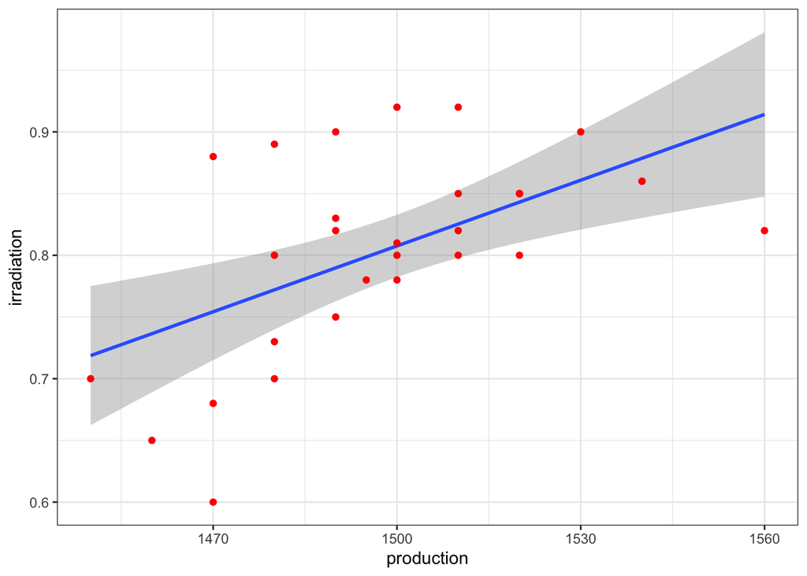

```r
solar_df %>%
  ggplot(aes(x=production,y=irradiation)) +
  geom_smooth(method = "lm") +
  geom_point(color="red") +
  theme_bw()
```

This relationship does appear positively linear, albeit with a large SD

## #11

```r
model <- lm(solar_df$production~solar_df$temp + solar_df$irradiation)

summary(model)
```

```
##
## Call:
## lm(formula = solar_df$production ~ solar_df$temp + solar_df$irradiation)
##
## Residuals:
##     Min      1Q  Median      3Q     Max
## -40.267 -11.940   2.212  12.607  54.340
##
## Coefficients:
##                      Estimate Std. Error t value Pr(>|t|)
## (Intercept)          1369.646     44.914  30.495   <2e-16 ***
## solar_df$temp           1.141      1.791   0.637    0.529
## solar_df$irradiation  133.858     83.377   1.605    0.120
## ---
## Signif. codes:  0 '***' 0.001 '**' 0.01 '*' 0.05 '.' 0.1 ' ' 1
##
## Residual standard error: 21.54 on 27 degrees of freedom
## Multiple R-squared:  0.3237, Adjusted R-squared:  0.2736
## F-statistic:  6.46 on 2 and 27 DF,  p-value: 0.005097
```

R^2 is 0.32 and p value is 0.005. These values are significant.

## #12

Given the model, and increase of 5 degrees would make the production go up by x*1.141: causing a 5.705 kWh increase in production.

## #13

Here is the summary of the model created only by the cumulative degradation:

```r
model <- lm(solar_df$production~solar_df$degrade_cumulative)

summary(model)
```

```
##
## Call:
## lm(formula = solar_df$production ~ solar_df$degrade_cumulative)
##
## Residuals:
##     Min      1Q  Median      3Q     Max
## -47.586 -18.861  -1.269  16.467  60.431
##
## Coefficients:
##                              Estimate Std. Error t value Pr(>|t|)
## (Intercept)                 1495.5563     9.4346 158.519   <2e-16 ***
## solar_df$degrade_cumulative    0.2361     0.4905   0.481    0.634
## ---
## Signif. codes:  0 '***' 0.001 '**' 0.01 '*' 0.05 '.' 0.1 ' ' 1
##
## Residual standard error: 25.61 on 28 degrees of freedom
## Multiple R-squared:  0.008204,   Adjusted R-squared:  -0.02722
## F-statistic: 0.2316 on 1 and 28 DF,  p-value: 0.6341
```

And here is a plot of that

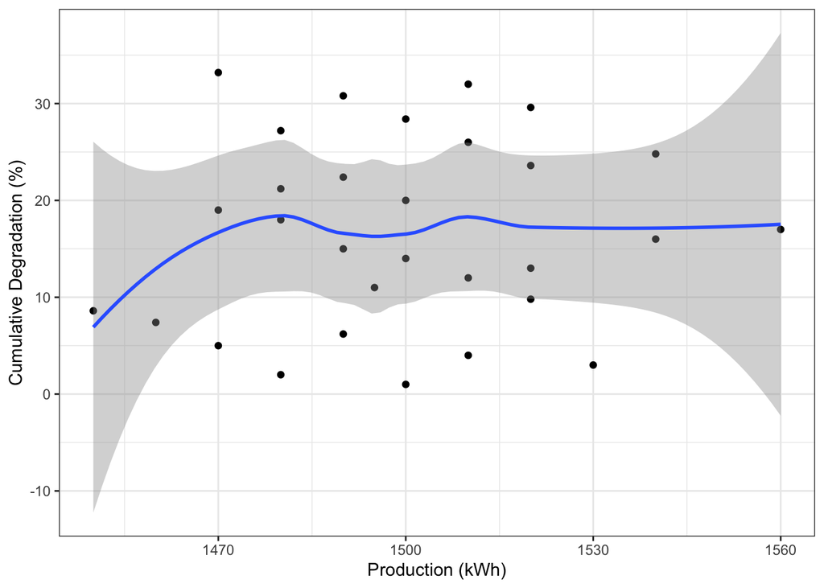

```r
solar_df %>%
  ggplot(aes(x=production,y=degrade_cumulative)) +
  geom_point() +
  geom_smooth() +
  theme_bw() +
  labs(x="Production (kWh)",
       y="Cumulative Degradation (%)")
```

This plot shows nearly 0 correlation.

```r
cat("Total degradation:", sum(solar_df$degrade_percent), "%")
```

```
## Total degradation: 33.2 %
```

## #14

```r
# 1 kWh = 0.0036 GJ
#total production in GJ
cat("Total production:",sum(solar_df$production) * 0.0036,"GJ")
```

```
## Total production: 161.946 GJ
```

## #15

```r
kW <- solar_df$production / 12

total_kW <- sum(kW)

cat("Total kW generated:",total_kW)
```

```
## Total kW generated: 3748.75
```